# Confirmatory Models: Inequality and Youth Protest Disposition

Preregistered primary specification (CivED 1999, ICCS 2009/2016/2022)

## 1 Design summary

- **Outcomes** (1 = certainly not … 4 = certainly would do; ICCS items reversed to match CivED): *peaceful march* and *block traffic*.
- **Model** (preregistered): $Y_{ict} = \beta_0 + \beta_1 \text{Gini}_{ct} + \beta_2\text{female} + \beta_3\text{civic\_z} + \beta_4\text{parents\_univ} + \gamma_t + u_c + \varepsilon_{ict}$, with a country random intercept and wave fixed effects.
- **Primary estimator**: weighted two-level model (`WeMix`), student total weights rescaled within country-wave, cluster-robust SEs. **Comparison**: unweighted `lme4::lmer`.
- Gini: SWIID v9.92 disposable-income Gini (0–100) for the survey year. Civic knowledge standardized within wave.

Analytic samples (complete cases)

| Outcome | Students | Countries | Country-waves |
| --- | --- | --- | --- |
| Peaceful march | 361,233 | 48 | 112 |
| Block traffic | 364,256 | 48 | 112 |

## 2 Main results

Fixed effects, 95% CI in brackets. * p<.05, ** p<.01, *** p<.001 (two-sided).

|  | Peaceful march — WeMix (weighted, primary) | Peaceful march — lmer (unweighted) | Block traffic — WeMix (weighted, primary) | Block traffic — lmer (unweighted) |
| --- | --- | --- | --- | --- |
| Gini (1 point) | -0.008 [-0.029, 0.013] | -0.007*** [-0.010, -0.005] | -0.020* [-0.038, -0.002] | -0.020*** [-0.022, -0.017] |
| Female (ref. male) | 0.023 [-0.009, 0.056] | 0.023*** [0.018, 0.029] | -0.177*** [-0.196, -0.157] | -0.175*** [-0.180, -0.169] |
| Civic knowledge (z) | 0.088*** [0.069, 0.108] | 0.089*** [0.086, 0.092] | -0.200*** [-0.223, -0.177] | -0.200*** [-0.204, -0.197] |
| University-educated parent | 0.008 [-0.013, 0.028] | 0.010** [0.003, 0.016] | -0.001 [-0.012, 0.010] | -0.003 [-0.009, 0.004] |
| Wave 2009 (ref. 1999) | 0.150** [0.038, 0.263] | 0.136*** [0.127, 0.146] | 0.134** [0.048, 0.220] | 0.124*** [0.115, 0.133] |
| Wave 2016 | 0.164** [0.047, 0.281] | 0.155*** [0.145, 0.166] | 0.132** [0.041, 0.224] | 0.128*** [0.118, 0.138] |
| Wave 2022 | 0.089 [-0.014, 0.193] | 0.080*** [0.069, 0.090] | 0.179*** [0.089, 0.270] | 0.171*** [0.160, 0.181] |

Country-level variance (lmer)

| Outcome | ICC (country, null model) | Country variance (conditional model) |
| --- | --- | --- |
| Peaceful march | 0.067 | 0.084 |
| Block traffic | 0.051 | 0.061 |

## 3 Hypothesis evaluation (preregistered criteria)

Decision rule (Q7): supported if the coefficient has the expected sign and its 95% CI excludes zero; contradicted if opposite sign with CI excluding zero; otherwise inconclusive. H2 is non-directional. Evaluated on the primary (WeMix) estimates.

|  | Hypothesis | Expected | Outcome | b [95% CI] | p | Result |
| --- | --- | --- | --- | --- | --- | --- |
| H1 | Higher inequality → more protest disposition | + | Block traffic | -0.020 [-0.038, -0.002] | 0.026 | Contradicted |
| H1 | Higher inequality → more protest disposition | + | Peaceful march | -0.008 [-0.029, 0.013] | 0.466 | Inconclusive |
| H2 | Gender is associated with protest disposition | ≠ 0 | Block traffic | -0.177 [-0.196, -0.157] | <.001 | Supported |
| H2 | Gender is associated with protest disposition | ≠ 0 | Peaceful march | 0.023 [-0.009, 0.056] | 0.159 | Inconclusive |
| H3 | Civic knowledge → less protest disposition | − | Block traffic | -0.200 [-0.223, -0.177] | <.001 | Supported |
| H3 | Civic knowledge → less protest disposition | − | Peaceful march | 0.088 [0.069, 0.108] | <.001 | Contradicted |
| H4 | University-educated parent → more protest disposition | + | Block traffic | -0.001 [-0.012, 0.010] | 0.909 | Inconclusive |
| H4 | University-educated parent → more protest disposition | + | Peaceful march | 0.008 [-0.013, 0.028] | 0.474 | Inconclusive |

## 4 Figures

### 4.1 Coefficient plot

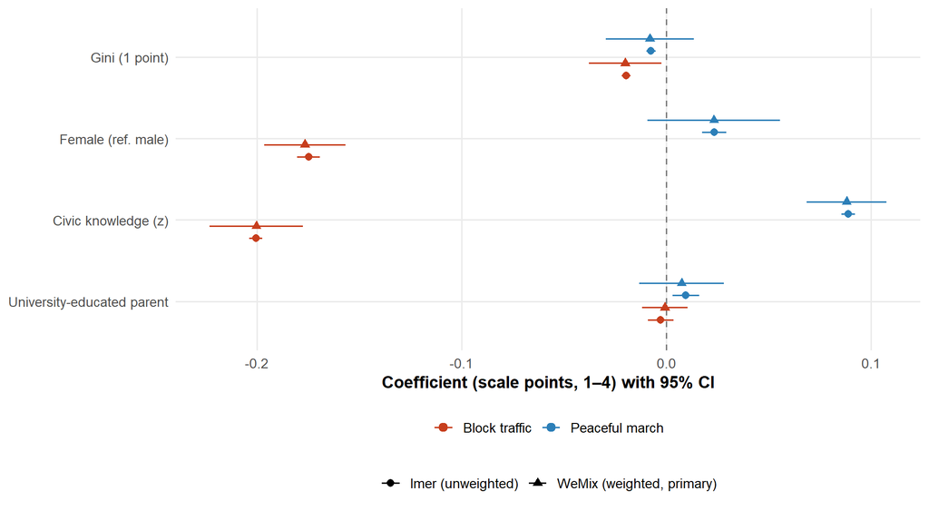

## 5 Prespecified robustness F: country-wave random intercept

Gini varies at the **country-wave** level. The primary model has only a country random intercept, and each country contributes thousands of students. In that setup the Gini slope is identified almost entirely by *within-country change over time*. Across country-waves, Gini has a between-country SD of about 7 points but a within-country SD of only about 1.3 points. The primary coefficient therefore does not estimate the between-country contrast stated in H1. Adding the country-wave random intercept (prespecified robustness analysis F) models the level where Gini varies. It also matches the specification of the earlier INVALSI 2022 analyses (see the reconciliation section below).

Focal coefficients by random-effects structure (95% CI)

|  | Peaceful march — Primary: country RE (WeMix) | Peaceful march — Country + country-wave RE (lmer) | Peaceful march — Country + country-wave RE (WeMix) | Block traffic — Primary: country RE (WeMix) | Block traffic — Country + country-wave RE (lmer) | Block traffic — Country + country-wave RE (WeMix) |
| --- | --- | --- | --- | --- | --- | --- |
| Gini (1 point) | -0.008 [-0.029, 0.013] | 0.019*** [0.012, 0.027] | 0.020*** [0.013, 0.027] | -0.020* [-0.038, -0.002] | 0.005 [-0.001, 0.011] | 0.005* [0.001, 0.009] |
| Female (ref. male) | 0.023 [-0.009, 0.056] | 0.023*** [0.018, 0.029] | 0.024 [-0.009, 0.057] | -0.177*** [-0.196, -0.157] | -0.174*** [-0.180, -0.169] | -0.175*** [-0.196, -0.155] |
| Civic knowledge (z) | 0.088*** [0.069, 0.108] | 0.086*** [0.083, 0.089] | 0.084*** [0.068, 0.101] | -0.200*** [-0.223, -0.177] | -0.202*** [-0.205, -0.199] | -0.203*** [-0.225, -0.180] |
| University-educated parent | 0.008 [-0.013, 0.028] | 0.015*** [0.009, 0.022] | 0.012 [-0.005, 0.029] | -0.001 [-0.012, 0.010] | 0.002 [-0.004, 0.008] | 0.003 [-0.006, 0.012] |

Hypothesis evaluation under robustness F

|  | Outcome | Model | b [95% CI] | p | Result |
| --- | --- | --- | --- | --- | --- |
| H1 | Block traffic | Country + country-wave RE (WeMix) | 0.005 [0.001, 0.009] | 0.016 | Supported |
| H1 | Block traffic | Country + country-wave RE (lmer) | 0.005 [-0.001, 0.011] | 0.097 | Inconclusive |
| H1 | Peaceful march | Country + country-wave RE (WeMix) | 0.020 [0.013, 0.027] | <.001 | Supported |
| H1 | Peaceful march | Country + country-wave RE (lmer) | 0.019 [0.012, 0.027] | <.001 | Supported |
| H2 | Block traffic | Country + country-wave RE (WeMix) | -0.175 [-0.196, -0.155] | <.001 | Supported |
| H2 | Block traffic | Country + country-wave RE (lmer) | -0.174 [-0.180, -0.169] | <.001 | Supported |
| H2 | Peaceful march | Country + country-wave RE (WeMix) | 0.024 [-0.009, 0.057] | 0.151 | Inconclusive |
| H2 | Peaceful march | Country + country-wave RE (lmer) | 0.023 [0.018, 0.029] | <.001 | Supported |
| H3 | Block traffic | Country + country-wave RE (WeMix) | -0.203 [-0.225, -0.180] | <.001 | Supported |
| H3 | Block traffic | Country + country-wave RE (lmer) | -0.202 [-0.205, -0.199] | <.001 | Supported |
| H3 | Peaceful march | Country + country-wave RE (WeMix) | 0.084 [0.068, 0.101] | <.001 | Contradicted |
| H3 | Peaceful march | Country + country-wave RE (lmer) | 0.086 [0.083, 0.089] | <.001 | Contradicted |
| H4 | Block traffic | Country + country-wave RE (WeMix) | 0.003 [-0.006, 0.012] | 0.507 | Inconclusive |
| H4 | Block traffic | Country + country-wave RE (lmer) | 0.002 [-0.004, 0.008] | 0.556 | Inconclusive |
| H4 | Peaceful march | Country + country-wave RE (WeMix) | 0.012 [-0.005, 0.029] | 0.175 | Inconclusive |
| H4 | Peaceful march | Country + country-wave RE (lmer) | 0.015 [0.009, 0.022] | <.001 | Supported |

## 6 Wave-by-wave models

These are separate models per wave (country random intercept, same covariates, unweighted), comparable to the wave-specific INVALSI 2022 tables.

Gini coefficient by wave

| Outcome | Wave | Countries | b Gini | 95% CI |
| --- | --- | --- | --- | --- |
| Peaceful march | 1999 | 28 | 0.011 | [-0.003, 0.026] |
| Peaceful march | 2009 | 37 | 0.025 | [0.017, 0.034] |
| Peaceful march | 2016 | 24 | 0.032 | [0.020, 0.044] |
| Peaceful march | 2022 | 23 | 0.014 | [0.003, 0.024] |
| Block traffic | 1999 | 28 | 0.002 | [-0.007, 0.012] |
| Block traffic | 2009 | 37 | 0.002 | [-0.005, 0.008] |
| Block traffic | 2016 | 24 | 0.019 | [0.010, 0.027] |
| Block traffic | 2022 | 23 | 0.009 | [0.001, 0.017] |

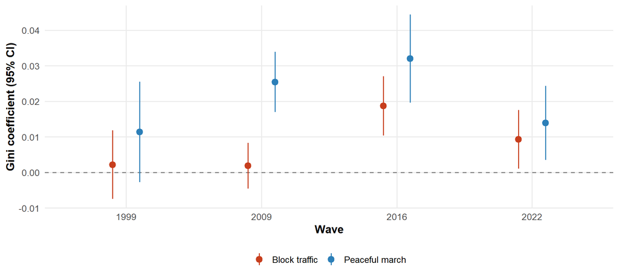

### 6.1 Country-wave means and the Gini effect

Points are weighted country-wave means. The lines are model-implied Gini slopes anchored at the overall mean: solid for country + country-wave RE, dashed for the primary country-RE model.

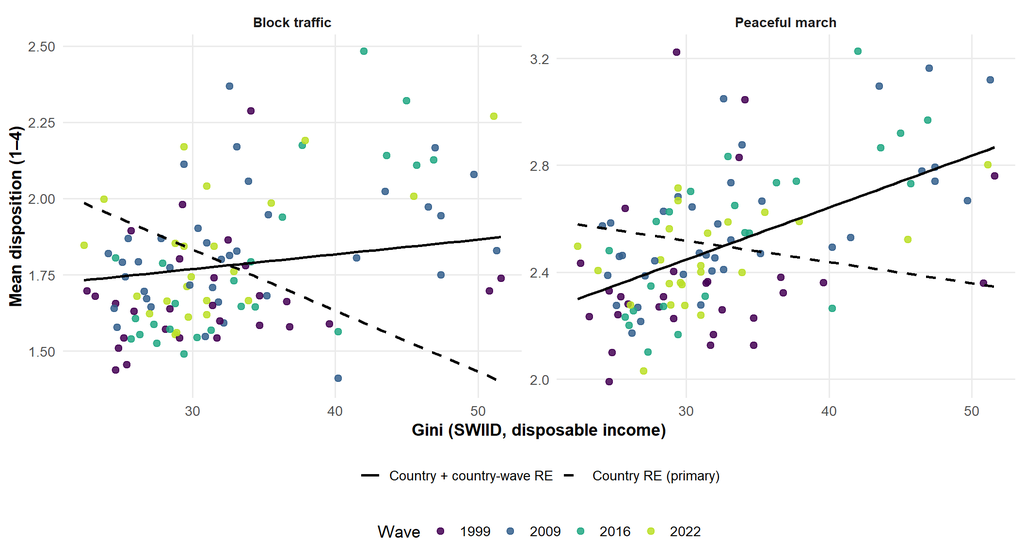

### 6.2 Substantive size of the Gini effect

Implied differences in disposition (1–4 scale)

| Outcome | Model | Effect of +1 SD Gini | P10→P90 Gini | Effect P10→P90 |
| --- | --- | --- | --- | --- |
| Peaceful march | Primary: country RE (WeMix) | -0.058 | 25.1 → 45.5 | -0.162 |
| Peaceful march | Country + country-wave RE (lmer) | 0.141 | 25.1 → 45.5 | 0.395 |
| Peaceful march | Country + country-wave RE (WeMix) | 0.144 | 25.1 → 45.5 | 0.402 |
| Block traffic | Primary: country RE (WeMix) | -0.145 | 25.1 → 45.5 | -0.407 |
| Block traffic | Country + country-wave RE (lmer) | 0.035 | 25.1 → 45.5 | 0.098 |
| Block traffic | Country + country-wave RE (WeMix) | 0.037 | 25.1 → 45.5 | 0.105 |

## 7 Reconciliation with the INVALSI 2022 analyses

The INVALSI 2022 Stata models (pooled 1999–2016, radical index) reported a positive Gini effect (b ≈ 0.01, t ≈ 4.7). The table below moves step by step from that specification to the preregistered one, using the corrected pooled data (unweighted lmer, ML).

Gini coefficient (SE) across specifications

| Specification | Radical index | Block traffic | Peaceful march | Pacific index |
| --- | --- | --- | --- | --- |
| A. INVALSI replica: country-year + school RE, pct_know | 0.0135 (0.0027)*** | 0.0127 (0.0028)*** | 0.0198 (0.0032)*** | 0.0216 (0.0023)*** |
| B. A with 2022 added | 0.0139 (0.0025)*** | 0.0134 (0.0025)*** | 0.0187 (0.0028)*** | 0.0201 (0.0021)*** |
| C. B without school level | 0.0137 (0.0025)*** | 0.0133 (0.0025)*** | 0.0186 (0.0028)*** | 0.0199 (0.0021)*** |
| D. C with civic_z (within wave) instead of pct_know | 0.0070 (0.0021)*** | 0.0066 (0.0022)** | 0.0214 (0.0029)*** | 0.0213 (0.0022)*** |
| E. Country RE + country-year RE, civic_z | 0.0054 (0.0027)* | 0.0048 (0.0028) | 0.0194 (0.0036)*** | 0.0201 (0.0027)*** |
| F. Preregistered: country RE only, civic_z | -0.0175 (0.0010)*** | -0.0195 (0.0011)*** | -0.0074 (0.0012)*** | -0.0039 (0.0009)*** |
| G. Country RE only, pct_know | -0.0186 (0.0010)*** | -0.0206 (0.0011)*** | -0.0069 (0.0012)*** | -0.0036 (0.0009)*** |

- **Specification A reproduces the INVALSI result** with the corrected data (b ≈ 0.013 for the radical index).
- Adding 2022 or dropping the school level (B, C) does not change it.
- Using within-wave instead of within-country civic knowledge (D) roughly halves the effect for radical actions. Within-wave scores carry between-country knowledge differences, which correlate with Gini.
- The **sign changes only when the country-wave level is removed** (F, G). That is the random-effects structure of the preregistered primary model, and it identifies Gini from within-country change.
- Item note: the INVALSI 2016 indices used IS3G31B (*vote in national elections*) in the pacific index and IS3G31I (*volunteer time to help people*) in the radical index. The equivalent protest items are IS3G30B (*contact representative*) and IS3G30I (*spray slogans*). The indices above use the correct protest items in every wave and still reproduce the INVALSI Gini result.
- The two Gini sources are nearly identical: the INVALSI hand-coded values and SWIID v9.92 agree closely for 1999–2016.

## 8 Notes

- Sections 2–3 report the **preregistered primary** model. The country-wave model is **prespecified robustness analysis F**. The reconciliation section is exploratory. Other robustness analyses (A–E) are pending.
- Data processing corrections made before estimation (all verified against IEA value labels): ICCS 2009/2016/2022 participation items reversed to the CivED direction; gender coding corrected for ICCS 2016 and 2022 (raw 1 = girl); valid parental-education code 0 retained; binary university indicator built per wave.